# Practical Machine Leaerning: Prediction Assignment Writeup

Muhammad Mubashir

11/27/2020

# Overview

The main goal of the project is to predict the manner in which 6 participants performed some exercise as described below. This is the “classe” variable in the training set. The machine learning algorithm described here is applied to the 20 test cases.

# Background

Using devices such as Jawbone Up, Nike FuelBand, and Fitbit it is now possible to collect a large amount of data about personal activity relatively inexpensively. These type of devices are part of the quantified self movement - a group of enthusiasts who take measurements about themselves regularly to improve their health, to find patterns in their behavior, or because they are tech geeks. One thing that people regularly do is quantify how much of a particular activity they do, but they rarely quantify how well they do it. In this project, your goal will be to use data from accelerometers on the belt, forearm, arm, and dumbell of 6 participants. They were asked to perform barbell lifts correctly and incorrectly in 5 different ways.

# Getting and Cleaning Data

### Data Sources

The training data is availabe at this [link](https://d396qusza40orc.cloudfront.net/predmachlearn/pml-training.csv) and the test data is avaialabe at this [link](https://d396qusza40orc.cloudfront.net/predmachlearn/pml-testing.csv).  
### Dataset Overview  
A short description of the datasets content from the authors’ website:  
“Six young health participants were asked to perform one set of 10 repetitions of the Unilateral Dumbbell Biceps Curl in five different fashions: exactly according to the specification (Class A), throwing the elbows to the front (Class B), lifting the dumbbell only halfway (Class C), lowering the dumbbell only halfway (Class D) and throwing the hips to the front (Class E).  
Class A corresponds to the specified execution of the exercise, while the other 4 classes correspond to common mistakes. Participants were supervised by an experienced weight lifter to make sure the execution complied to the manner they were supposed to simulate. The exercises were performed by six male participants aged between 20-28 years, with little weight lifting experience. We made sure that all participants could easily simulate the mistakes in a safe and controlled manner by using a relatively light dumbbell (1.25kg).”

## Load Data into Environment

```r
# set the URL for the download
UrlTrain <- "http://d396qusza40orc.cloudfront.net/predmachlearn/pml-training.csv"
UrlTest  <- "http://d396qusza40orc.cloudfront.net/predmachlearn/pml-testing.csv"
train_in <- read.csv(url(UrlTrain))
validation  <- read.csv(url(UrlTest))
```

## Data Partition and Removing zero-values-columns

Since I’ll be predicting classes in the testing dataset, I’ll split the training data into training and testing partitions and use the pml-testing.csv as a validation sample. I’ll use cross validation within the training partition to improve the model fit and then do an out-of-sample test with the testing partition.

```r
training_sample <- createDataPartition(y=train_in$classe, p=0.7, list=FALSE)
training <- train_in[training_sample, ]
testing <- train_in[-training_sample, ]

all_zero_colnames <- sapply(names(validation), function(x) all(is.na(validation[,x])==TRUE))
nznames <- names(all_zero_colnames)[all_zero_colnames==FALSE]
nznames <- nznames[-(1:7)]
nznames <- nznames[1:(length(nznames)-1)]
corMatrix <- cor(training[nznames][, -52])
#corrplot(corMatrix, order = "FPC", method = "color", type = "lower",
#         tl.cex = 0.8, tl.col = rgb(0, 0, 0))
#size exceeds one mb, (can't view in github), so plot is commented out
```

[output not shown]

# Machine Learning Models

The following two models will be used for prediction, the one with high accuracy will be selected.

```r
fitControl <- trainControl(method='cv', number = 5)
model_cart <- train(
  classe ~ .,
  data=training[, c('classe', nznames)],
  trControl=fitControl,
  method='rpart'
)
save(model_cart, file='./ModelFitCART.RData')

model_rf <- train(
  classe ~ .,
  data=training[, c('classe', nznames)],
  trControl=fitControl,
  method='rf',
  ntree=100
)
save(model_rf, file='./ModelFitRF.RData')

# cross validation
#Cross validation is done for each model with K = 5
fitControl <- trainControl(method='cv', number = 5)
```

## Models Evaluation/Assesment

```r
predCART <- predict(model_cart, newdata=testing)
cmCART <- confusionMatrix(predCART, testing$classe)
predRF <- predict(model_rf, newdata=testing)
cmRF <- confusionMatrix(predRF, testing$classe)
AccuracyResults <- data.frame(
  Model = c('CART', 'RF'),
  Accuracy = rbind(cmCART$overall[1], cmRF$overall[1])
)
print(AccuracyResults)
```

```
##   Model  Accuracy
## 1  CART 0.4875106
## 2    RF 0.9918437
```

Based on an evaluation of these 2 model fits and out-of-sample results, it looks like random forests outperforms the CART model. The confusion matrix for the random forest model is below.

```r
cmRF$table
```

```
##           Reference
## Prediction    A    B    C    D    E
##          A 1670    2    0    0    1
##          B    3 1133   12    0    1
##          C    1    3 1006   12    0
##          D    0    1    8  951    3
##          E    0    0    0    1 1077
```

The most important feature are listed below, as well as shown in graph below.

```r
 # make dataframe from importance() output
varImp(model_rf)
```

```
## rf variable importance
##
##   only 20 most important variables shown (out of 52)
##
##                      Overall
## roll_belt            100.000
## pitch_forearm         57.602
## yaw_belt              49.839
## magnet_dumbbell_y     44.712
## roll_forearm          43.090
## pitch_belt            41.943
## magnet_dumbbell_z     40.678
## accel_dumbbell_y      21.986
## total_accel_dumbbell  15.978
## accel_forearm_x       14.985
## roll_dumbbell         14.735
## magnet_dumbbell_x     14.642
## accel_dumbbell_z      13.867
## magnet_belt_z         12.877
## magnet_belt_y         12.186
## magnet_forearm_z      11.908
## accel_belt_z          11.659
## gyros_belt_z          10.996
## yaw_arm                9.805
## magnet_belt_x          8.476
```

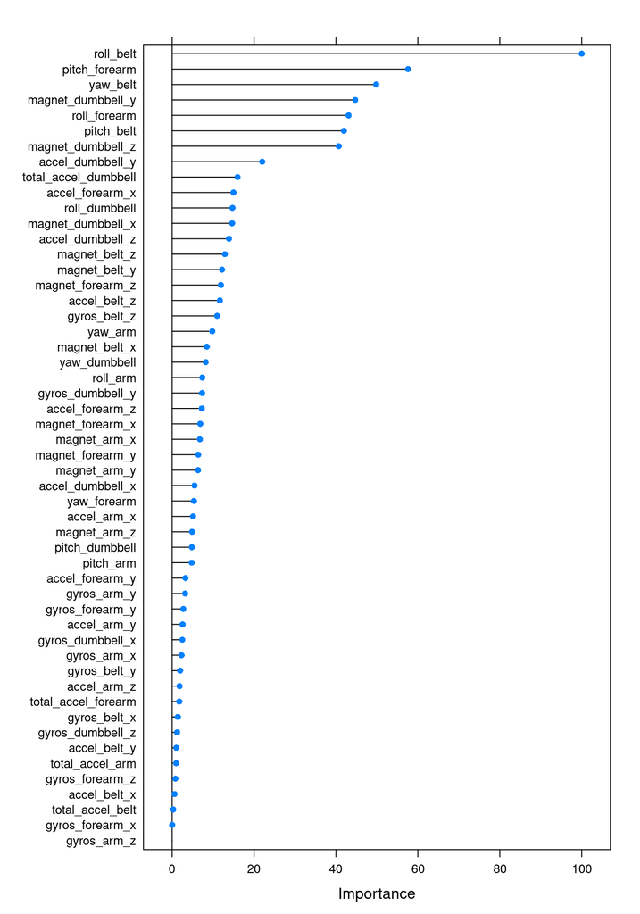

```r
plot(varImp(model_rf))
```

# Prediction

In the last step, predict the output class for the testing data (**pml-testing.csv**).

```r
predValidation <- predict(model_rf, newdata=validation)
ValidationPredictionResults <- data.frame(
  problem_id=validation$problem_id,
  predicted=predValidation
)
ValidationPredictionResults
```

```
##    problem_id predicted
## 1           1         B
## 2           2         A
## 3           3         B
## 4           4         A
## 5           5         A
## 6           6         E
## 7           7         D
## 8           8         B
## 9           9         A
## 10         10         A
## 11         11         B
## 12         12         C
## 13         13         B
## 14         14         A
## 15         15         E
## 16         16         E
## 17         17         A
## 18         18         B
## 19         19         B
## 20         20         B
```